# Prediction of protein pocket druggability

## 3.2.2 K-means

K-means clustering is a method to partition n observations into k clusters, in which each ob- servation belongs to the cluster with the nearest mean. The disadvantage of K-mean method is that you must know the number of clusters. 1. What are the input and output of the kmeans() function? 2. To test the kmeans procedure, firstly compute a kmeans with 2 clusters using the pocket descriptors. What are the outputs of the function? Are the group is homogeneous in terms of druggability?

```r
pockets.kmeans = kmeans(pockets[, -37], centers = 3)
pockets.kmeans$cluster
```

```
1K8Q 3F0R 1PWM 1U30 3IA4 2CL5 1LOX 2IVU 1XM6 2I0E 1RV1 3F1Q 1UDT 1KE6 1GWR 1V4S 1RWQ 1HW8 1SQN 1SQI 1K7F 1OWE 1KVO 1R9O 1QHI 2FB8 1J4I
   2    2    3    3    3    1    2    3    3    2    3    3    2    2    2    3    2    2    2    3    3    3    1    1    2    2    2
2AA2 2BR1 1HVR 1HVY 1T46 1XOZ 1M2Z 1IG3 3D4S 2GH5 2DQ7 1YVF 1VBM 1U4D 1O5R 1QPE 1GKC 2HIW 1RSZ 1YQY 1C14 1LPZ 1N2V 1UOU 3B68 2I1M 1FK9
   2    2    3    2    3    3    2    2    3    1    3    3    2    2    2    2    2    2    3    1    3    2    2    2    2    2    2
1Q41 1M17 2BXR 1JS3 1PMN 2G24 1YWR 1YWN 1R55 3ETR 1UNL 1R58 4COX 1E9X 1E66 1KZN 1O8B 1KTS 1OD8 1GPU 1OLQ 1C9Y 1G7V 1QMF 1F9G 2GSU 3PCM
   2    2    3    2    3    3    3    2    2    1    2    2    3    1    3    2    2    3    2    2    2    2    2    3    3    2    3
1HQG 1NNC 1ONZ 1PX4 1AJS 1V16 1G98 1MAI 1D09 1CG0 2GYI 1UCN 1B74 1FTH 1NLJ 1BLS 1QXO 1BMQ 1M0N 1JAK 3JDW 1ICJ 1X9D 1WVC 1KC7 1T03 1MOQ
   2    2    2    3    2    2    2    2    2    3    1    3    3    3    2    2    3    2    1    2    2    2    2    3    2    2    2
1EC9
   3
```

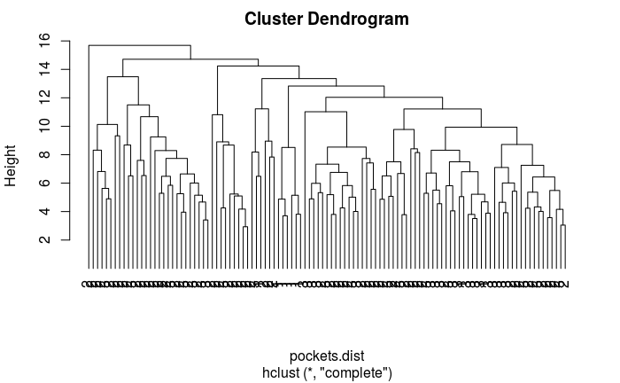

```r
plot(hclust(pockets.dist), hang = -1, labels = as.factor(pockets.kmeans$cluster))
```

```r
I.intra = rep(0, 10)
I.intra
```

```
 [1] 0 0 0 0 0 0 0 0 0 0
```

```r
for (i in 1:length(I.intra)){
  I.intra[i] = kmeans(pockets, centers = i)$tot.withinss
}
```

```r
plot(I.intra, type = "l", xlab = "Nombre de clusters", ylab = "Inertie intra-classe", main = "D?termination du nombre de cluster id?al par la m?thode des kmeans")
abline(v=3, col = "red")
```

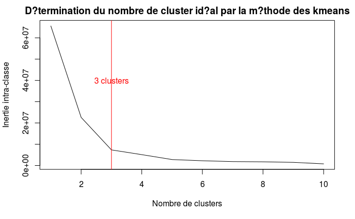

```r
text(3, 40000000, "3 clusters", col = "red")
```

3. As the K-means seeds are randomly chosen, it is important to perform the K-means several times. Re-preformed the mean procedure. What do you observe? Compare the occurrence of obtained groups. Are the kmeans results stable? Think to modify the seed of the random procedure. An important parameter in Kmeans procedure is the number of clusters to define. To determine this optimal number, you will use the procedure based on the analysis of the partition quality using parameters (R 2 , I W ). This procedure is the same used in hierarchical classification. The kmeans() function computes directly the intra-variability of each cluster.
4. Using this procedure, determine the optimal cluster number for pocket dataset.
5. Extract clusters from a K-means method using this optimal number. Compare the obtained partition with one extracted from the hierarchical classification.

## 3.2.3 Mixed method

The mixed approach consists to combine the advantages of the hierarchical classification and kmeans approaches. It consists in: • Step 1: Computation of an hierarchical classification from the dataset • Step 2: Define the optimal number k of clusters from this classification using I W and R 2 parameters of different partitions. • Step 3: Computation of the k clusters and their centres of gravity. • Step 4: Computation of a Kmeans procedure using the k centres of gravity as centers. The advantages of this method are that the initial centers are not randomly choosen and some individual reassignments are allowed. 1. Classify pockets using the mixed approach. 2. Are these clusters homogeneous in terms of druggability? 3. Which descriptors do separate the different pocket clusters? 4. Compare the partitions obtained using a hierarchical classification and kmeans.